# Assignment 5

Max Diamond and Nestor Collado

12/03/2019

## 1. Introduction

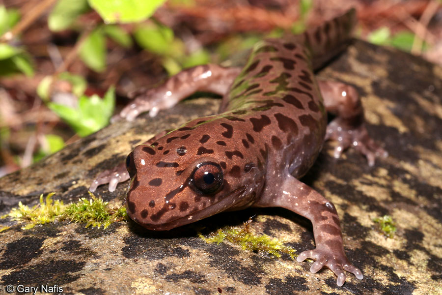

**Image 1:** *Pacific Giant Salamander. Credit: Gary Nafis for [California Herps](http://www.californiaherps.com/salamanders/pages/d.tenebrosus.html)*

Pacific Giant Salamanders, Dicamptodon tenebrosus, were surveyed in Oregon at the Andrews Experimental forest. This aquatic vertebrae study was sponsored and funded by the National Science Foundation’s [Long-Term Ecological Research Program](https://portal.lternet.edu/nis/mapbrowse?packageid=knb-lter-and.4027.12) (Andrews LTER). Researcher Stanley V. Gregory (2017) began observing populations in 1993, and has continued research into this day that has become one of the longest, uninterrupted studies of salamander populations recorded. In his surveys, Stanley observed Dicamptodon tenebrosus populations in two different settings, from which he gathered extensive data by weighing and measuring the salamanders.

Evaluating populations from old growth forest and a clear-cut forest reveals a study in contrasts regarding the salamanders’ day to day survival. One would imagine that in a clear-cut forest, the cutting down of trees would lead to soil erosion and excess run off into creeks. The lack of vegetation could have additional detrimental effects for healthy salamander populations, including a dwindling amount of hiding spaces with less vegetation (Sagar et al., 2007). All of this habitat destruction could have profound effects on biodiversity that would likely lead to a decrease in salamander population sizes and weights in clear-cut forest. In old growth forests, one would predict that salamander populations would be in a more stable environment, suggesting the population and weight of those samples would be more consistent and at healthier levels.

## 2. Data and methods

Data for Pacific Giant Salamander (*Dicamptodon tenebrosus*), forest condition and location were collected by Andrews LTER. The Pacific Giant Salamander population was monitored in two standard reaches of Mack Creek: a clear-cut forest (CC), and an upstream 500 year-old coniferous forest (OG).

The Pacific Giant Salamander abundance is sampled by live capture and with 2-pass electrofishing (Gregory, 2017). The salamander samples were observed in the pool (p), cascade (c) and side channel (SC) of the creek. A group of specimens were observed in isolated pools (IP), but they are not included in this analysis. For more information on collection methods, see [metada](https://portal.lternet.edu/nis/metadataviewer?packageid=knb-lter-and.4027.13).

We employ an exploratory data visualization (historical evolution, distribution and general statistics analysis) of the Pacific Giant Salamander counts, weight and distribution. Through a Chi2 (α = 0.05), we evaluate if there is a significant effect of forest condition (CC or OG) on where the salamanders are located (P, C and SC). Then, with ANOVA tests (α = 0.05), we analyze the following questions:

- Is there a significant difference in mean weights for Pacific giant salamanders observed in the two forest sections (CC vs OG)?
- Is there a significant difference in mean weights for Pacific giant salamanders observed according to where they are found (C vs SC vs P)?

Additionally, for the second question, we evaluate the effect size on weight means among locations.

All the calculations and tests are performed by **R software version 3.6.1.**

## 3. Results

### 3.1. Historical salamander abundance by forest condition

In 1993, both population counts started at almost the same level. However, between 1995 and 1999, the clear-cut forest salamander decline was alarming. In the year 2000, even though both populations experienced a steep rise, the clear-cut group experienced a greater surge; considering their relative decline. Until 2014, both groups experienced similar fluctuations, but the old growth population dominated in total quantity. However, after the population fall of 2013-2014, the clear-cut forest salamanders once again experience a notable increase, surpassing the old growth population.

The higher sample counts for clear-cut forest salamander may indicate its resilience and adaptive capacity to differing habitats.

[figure not shown]

### 3.2 Salamander abundance by location in the year 2017

Table 1: Number of salamanders by forest condition and location 2017

| Location | Clear cut | Old growth |
| --- | --- | --- |
| C | 247 (55.13%) | 201 (44.87%) |
| P | 31 (40.79%) | 45 (59.21%) |
| SC | 90 (54.88%) | 74 (45.12%) |

Own elaboration, source: Andrews LTER

If we maintain the hypothesis about the species resilience and adaptability, the clear-cut forest salamander is thriving as an opportunist, asserting itself in a new environment that presents less competition. However, this speculation goes against the reproductive lifestyle of this species: the Pacific Giant Salamander’s breeding ground are usually in still waters (Federal Energy Regulatory Comission, 2003). If the resilience hypothesis holds true, it suggests the salamanders have modified their behavior, switching to breeding in running waters. Nevertheless, this conjecture fails to explain how the larvae would manage to survive in a more hostile environment, especially when the absence of vegetation favors stronger currents.

### 3.3 Effect of forest condition on salamander abundance by location

Considering the discussion of the previous section, it is reasonable to test the effect of forest condition (clear cut and old growth) over the salamander abundance by where they are found. According to the results of the chi squared test, there is no significant association where the salamanders are found (cascade, pool and side channel) with the forest condition ($\chi^2$ (2) = 5.54, *p* = 0.06).

It would be premature to draw broad inferences from this test, considering we are only evaluating the year 2017 and not the whole period of available data. With all things considered, this might not be the most meaningful interpretation of the data, given it is the longest continuous record of salamander populations.

### 3.4 Mean weights of salamanders by forest condition 2017

The mean weights of the salamanders are strikingly similar, despite populations coming from such different habitats. Taking into account that the sample sizes are relatively close, the standard deviation and mean weight of each samples correspond closely to one another. The mean weight of clear-cut salamanders is just 1.2 grams above that of the old growth forest salamanders. At first glance, these statistics potentially weaken the preliminary claim that salamanders in clear-cut forests struggle and decrease in weight and count, when compared to salamanders from the old growth forest. Nonetheless, these samples consider only one year (2017), which restricts the data’s utility in deciphering more long-term patterns.

Table 2: General statistics of salamander weight by forest condition 2017

| Forest condition | Mean | SD | Sample size |
| --- | --- | --- | --- |
| CC | 7.78 | 9.90 | 368 |
| OG | 6.58 | 8.96 | 328 |

Own elaboration, source: Andrews LTER

[figure not shown]

The salamander’s weight doesnt present a normal distribution for any of the forest conditions (Appendix 1). However, the Leneve Test suggest we should retain the null hypothesis that weight variances between forest sections are equal (p-value=0.295, *p*<0.05). Considering its relative robustness even when the normality assupmtion does not apply, we will use the ANOVA test.

### 3.5 Mean weights of salamander by location 2017

The mean weights of the salamanders are different across locations. The salamanders found in pools weigh the most (9.3 grams) as expected to theory (Leigthon, 2011). In addition, the standard deviation differ in each case: there is greater spread in the pool salamander (13.6 grams) and less in the case of side channels (8.3 grams). However, it is neccessary to gather more information about pool salamanders because its sample’s size is relatively low when compared to the other locations.

Table 3: General statistics of salamander weight by location 2017

| Location | Mean | SD | Sample size |
| --- | --- | --- | --- |
| C | 7.52 | 9.03 | 448 |
| P | 9.30 | 13.62 | 76 |
| SC | 5.68 | 8.27 | 164 |

Own elaboration, source: Andrews LTER

All locations have numerous outliers that are considerably outside the standard their deviation range. In the case of cascade and side channel the major part of observations are clustered around the lower weight values. For pool salamanders, it seems the same pattern repeats but the relatively reduced number of observations can’t draw a definitive conclusion. In this context, the mean weight comparison might not be the most effective method because the samples present skewness and outliers.

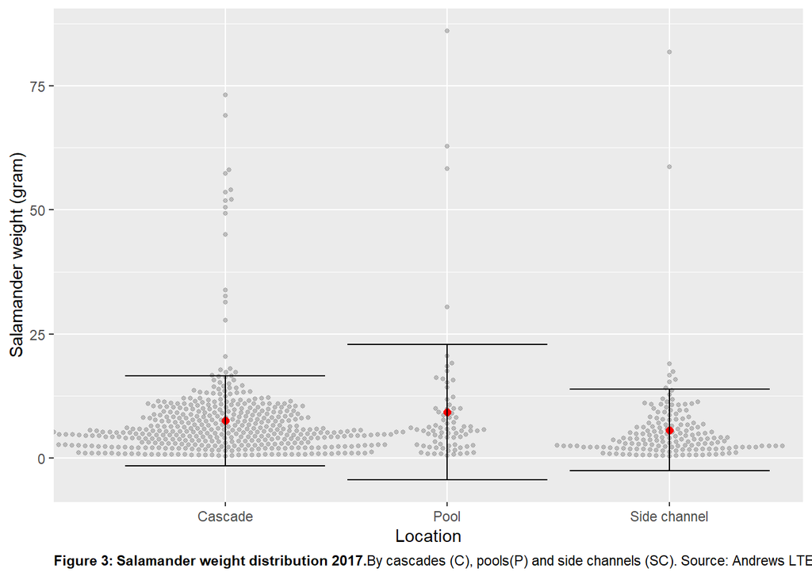

The salamander’s weight doesn’t present a normal distribution for any location (Appendix 2). However, the Leneve Test suggest we should retain the null hypothesis that weight variances between forest sections are equal (p-value=0.09, *p*<0.05). Considering its relative robustness even when the normality assumption does not apply, we will use the ANOVA test.

In addition, we employ a Cohen’s effect size test to quantify the difference of salamander weights by each pair of locations:

- Pool vs. side channel: the effect size is **moderate** (Cohen’s d= 0.35)
- Pool vs. cascade: the effect size is **low** (Cohen’s d= 0.18)
- Side channel vs. cascade: the effect size is **barely moderate** (Cohen’s d= 0.21)

In general, the difference in weight means are moderate across location groups (P vs SC and SC vs C), but the effect size for SD and C is nearer to a low value (0.21). In addition, as we mentioned, the Tukey test did not find a significant difference between SD and C. If we consider the Tukey test and apply a **conservative approach**, we determine there is no significant difference in mean weights for P vs. C and SC vs C. On the other hand, there is a moderate size effect for salamander found in pools versus side channels. This results seems reasonable if we consider that adult (and bigger) salamander prefer slow waters to mate and reproduce.

Finally, it is important to highlight that using mean tests aren’t the best approach for the current analysis. In **Figure 3**, we appreciate the presence of outliers observations and distribution concentration on the low weigth values. This skewness is also seen in Appendix 2. In this context, future research should use median based tests because they are less influenced by outlier values and distribution assymmetry. It is likely that under this context, some contradictions will be resolved. Moreover, we recommend to conduct this assessment through all the period of study to take advantage of the data series lengthy recorded history.

## References

Bull Run Hydroelectric Project, Federal Energy Regulatory Commission (2003). Environmental Impact Statement. Pages 148-152

Gregory S.V (2017). [Aquatic vertebrae population study in Mac Creek](https://portal.lternet.edu/nis/mapbrowse?packageid=knb-lter-and.4027.12). Data accessed on 12/03/2019.

Leighton, M. (2011). [Dicamptodon tenebrosus](https://animaldiversity.org/accounts/Dicamptodon_tenebrosus/#lifespan_longevity). Accessed December 03, 2019 at [Animal Diversity](https://animaldiversity.org/accounts/Dicamptodon_tenebrosus/)

Sagar, J., D. Olson, R. Schmitz (2007). Survival and Growth of Larval Coastal Giant Salamanders (Dicamptodon tenebrosus) in Streams in the Oregon Coast Range. Copeia, 1: pages 123-130.

## Appendix

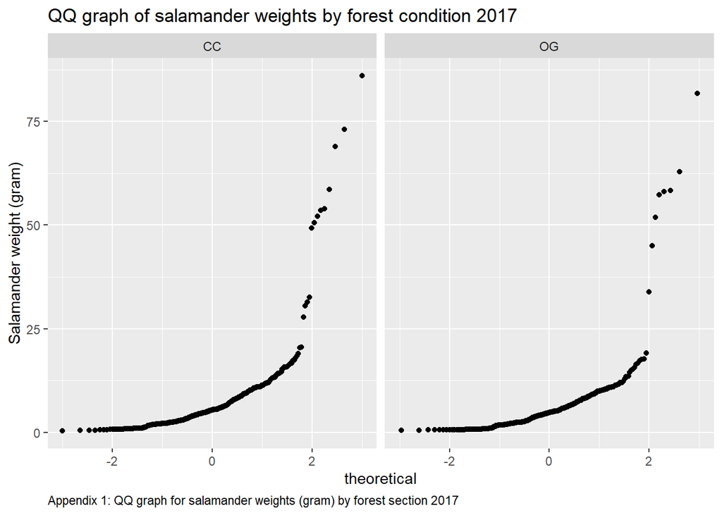

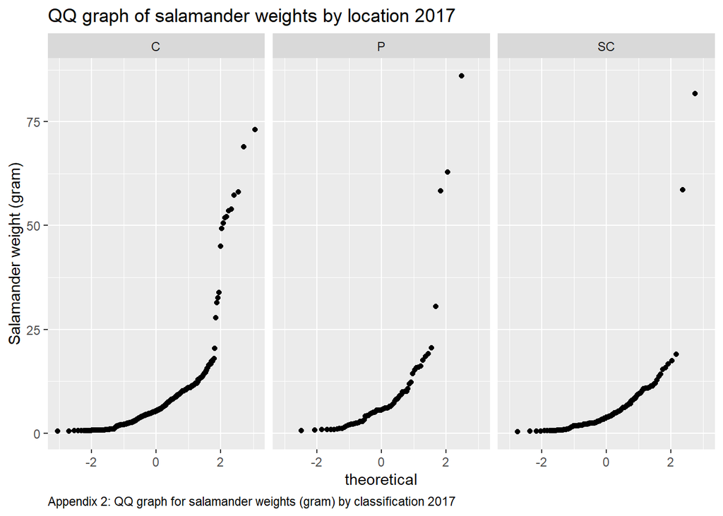